# ExploreCensus - MATH23C Final Project Highlights

## Visualizing Median Household Incomes

Upon cleaning up the dataset, we began our analysis by visualizing the median household incomes using a histogram. Overlaying the probability density graph for the normal distribution over the histogram, it became clear that median household incomes do not fall within this distribution.

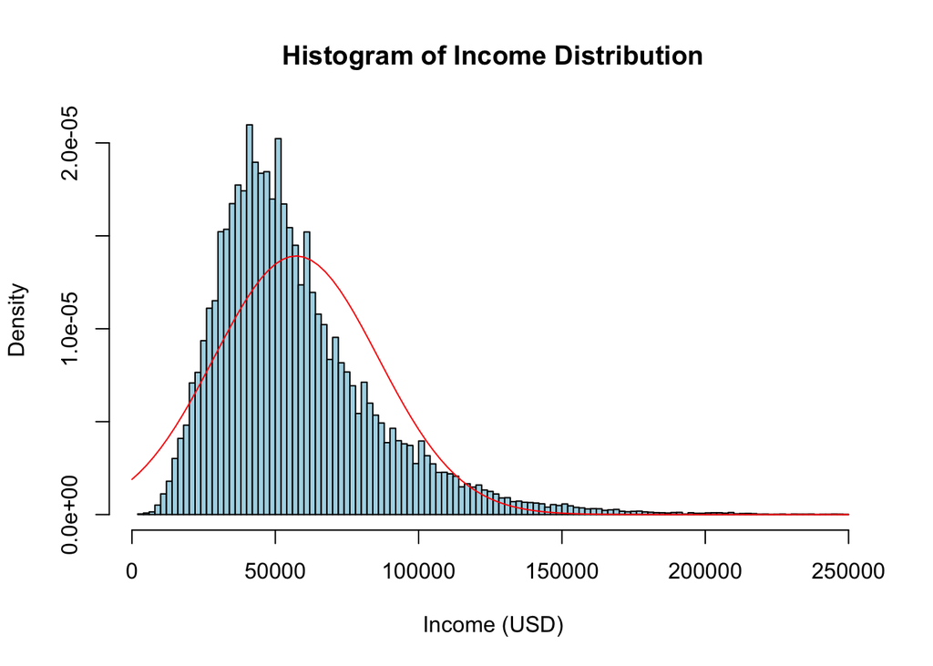

## Visualizng the Percentage of a Race in a Tract compared the Average Income of the Tract

We used scatterplots to visualize the percentage of a specific race in a tract with respect to the median income of the tract overall. In particular, we found that the slope for the Asian population was the most positive of all the scatterplots, reflecting broader trends amongst one of the fastest growing, highest-educated minority groups in the nation.

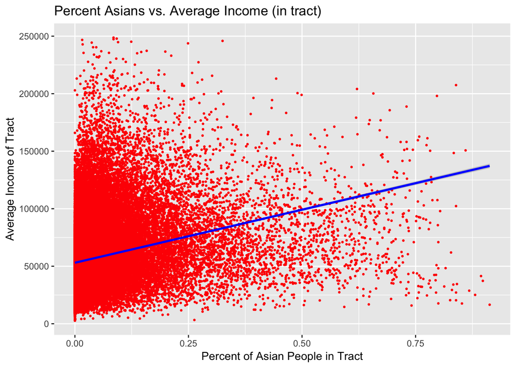

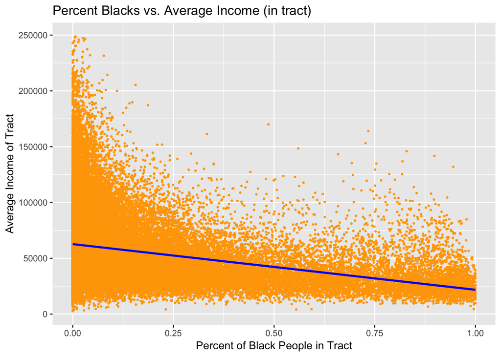

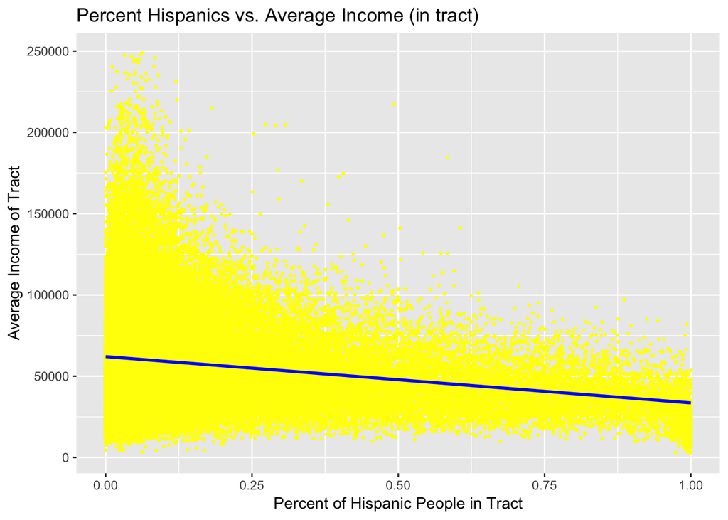

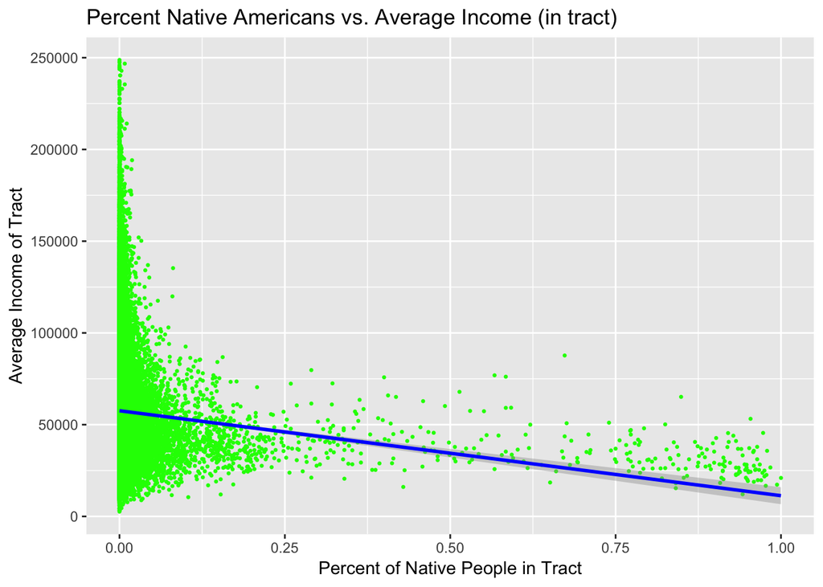

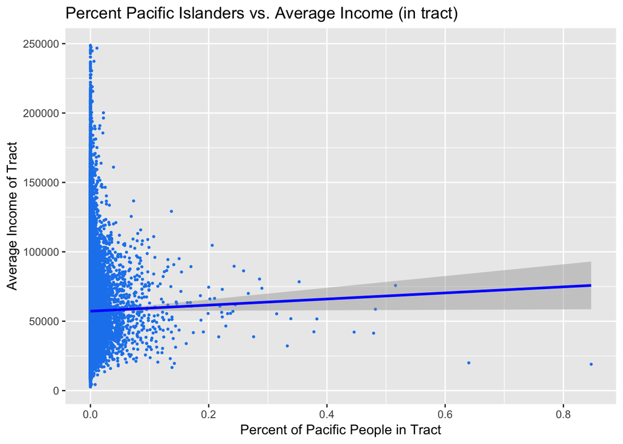

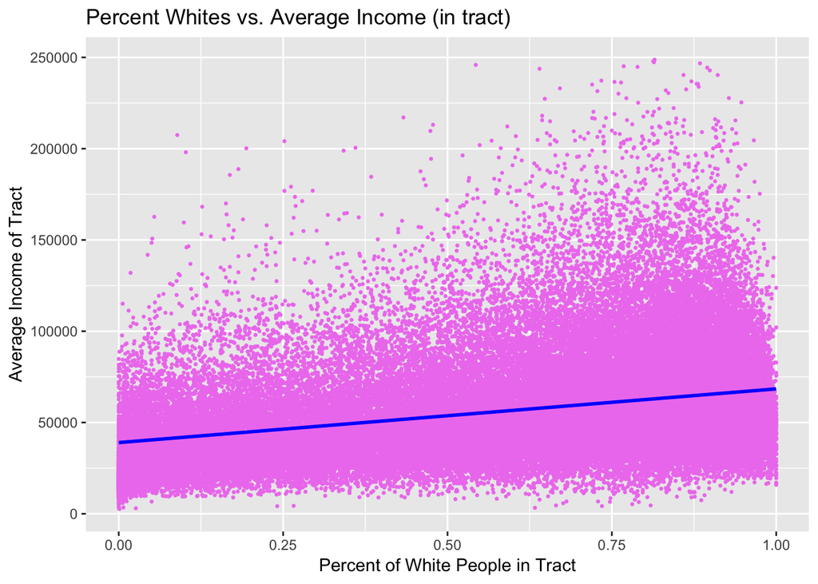

## Visualizng Trends through Bar Plots to Predict Income

We began by plotting the average income for tracts.

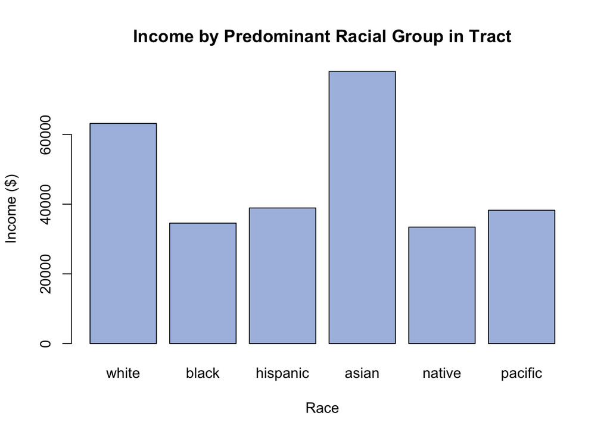

Given that the tracts with predominantly Asian populations (i.e., >50%) had the highest mean income, we tested to see if the income of these tracts were significantly greater than the other tracts.

```r
    #Predominantly Asian tracts have the highest average income
    #Is it significantly greater than each other race?
    w = asianincome - whiteincome
    b = asianincome - blackincome
    h = asianincome - hispanicincome
    n = asianincome - nativeincome
    p = asianincome - pacificincome

    s.w = var(mostlywhite)/length(mostlywhite)
    s.b = var(mostlyblack)/length(mostlyblack)
    s.h = var(mostlyhispanic)/length(mostlyhispanic)
    s.a = var(mostlyasian)/length(mostlyasian)
    s.n = var(mostlynative)/length(mostlynative)
    s.p = var(mostlypacific)/length(mostlypacific)

    t.w = w/sqrt(s.w+s.a)
    t.b = b/sqrt(s.b+s.a)
    t.h = h/sqrt(s.h+s.a)
    t.n = n/sqrt(s.n+s.a)
    t.p = p/sqrt(s.p+s.a)

    p.w = 1 - pnorm(t.w, 0, 1)
    p.b = 1 - pnorm(t.b, 0, 1)
    p.h = 1 - pnorm(t.h, 0, 1)
    p.n = 1 - pnorm(t.n, 0, 1)
    p.p = 1 - pnorm(t.p, 0, 1)

    p.w; p.b; p.h; p.n; p.p  #All of the differences are significant
```

```
## [1] 0
```

```
## [1] 0
```

```
## [1] 0
```

```
## [1] 0
```

```
## [1] 0.01700941
```

Ultimately, we found that the differences were clearly statisically significant in all cases.

We also used the percentage of people working in a “professional” industry (management, business, science, and arts) could be used as a predictor of being “wealthy” (median income over $50,000) in Massachusetts using a logistic regression curve. The curve demonstrated a pretty strong positive correlation, and the model gave fairly accurate predictions of the data

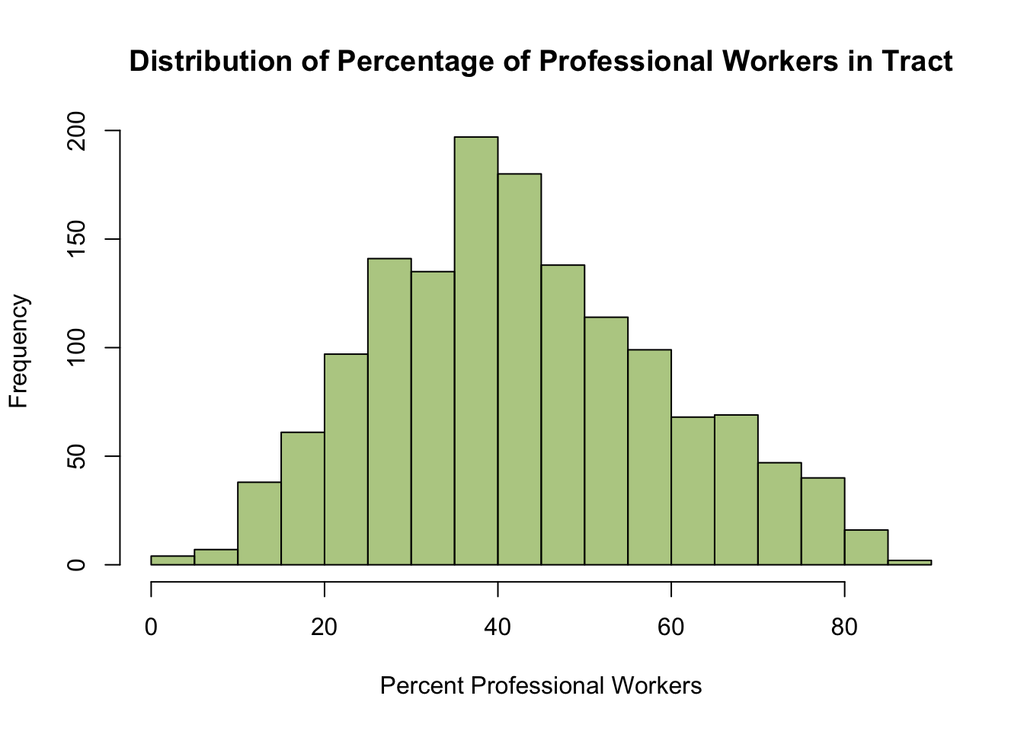

```
## [1] 0 0 1 1 1 0
```

```
##      alpha       beta
## -3.3996353  0.1237028
```

```
## [1]  57  58 113 116 133 153
```

```
## [1] 0.2121212
```

```
## [1] 11 25 38 61 64 73
```

```
## [1] 0.8701299
```

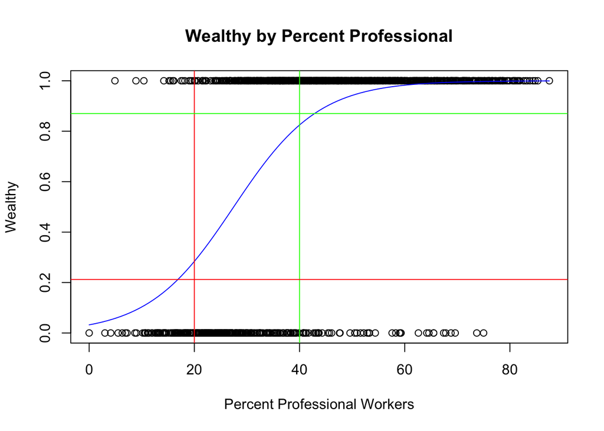